# MI in R

```r
library(lavaan)
library(dplyr)
habit <- read.table("sem_categorical.dat", header = FALSE)
```

This is a longer dataset, so we’ll add column names to the variables. Because we’re using the same dataset as the one for Mplus, missing values are still “.” At last line of code in this chunk tells R to turn all variables into numeric, which means that the “.” (which are character) will be turned into NAs - and that’s what we want.

```r
colnames(habit) <- c("age", "sex", "white", "child", "init",
    "inhib", "cont", "bfi", "psyeffect", "sched", "insec", "prehabit",
    "sl", "exer", "dt", "screen", "sm", "subs", "fri", "work",
    "hobby", "fam")

habit <- data.frame(lapply(habit, function(x) as.numeric(as.character(x))))
```

First, a quick overview of the data. If you use your own dataset, you’ll need to replace “habit” in the code with your dataset.

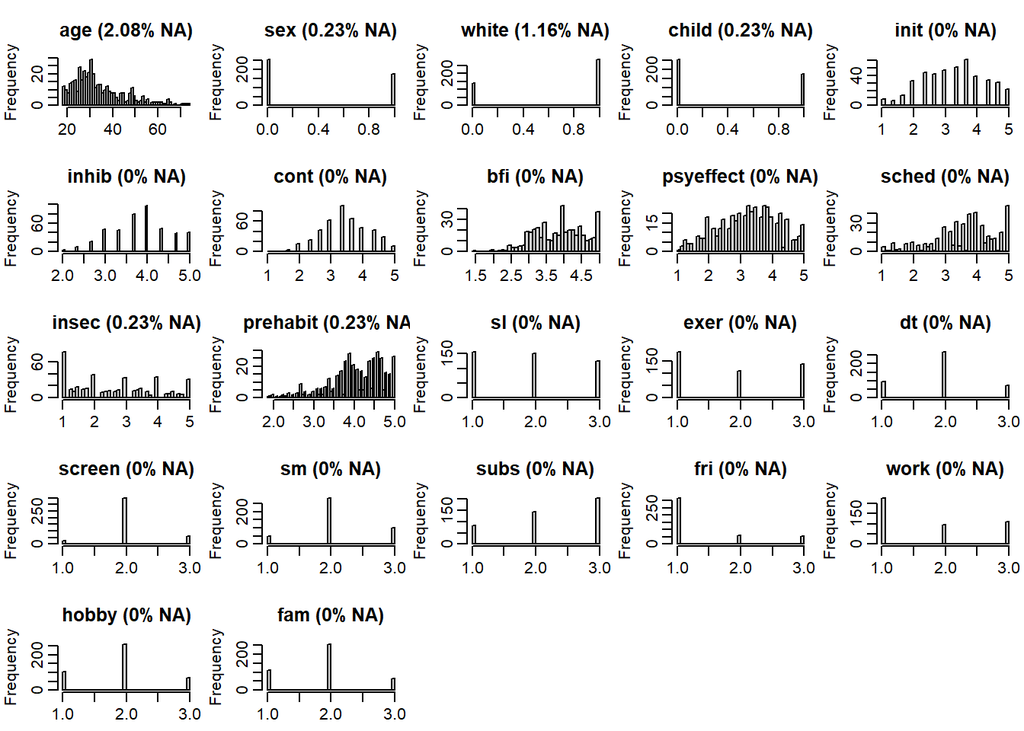

```r
nc <- max(5, ceiling(sqrt(ncol(habit))))
nr <- ceiling(ncol(habit)/nc)
par(mfrow = c(nr, nc), mgp = c(2, 0.6, 0), mar = c(2, 3, 3, 0.5))
for (i in 1:ncol(habit)) {
    if (is.numeric(habit[, i])) {
        hist(habit[, i], nclass = 50, xlab = "", main = paste0(names(habit[i]),
            " (", round(mean(is.na(habit[, i])) * 100, 2), "% NA)"))
    } else {
        barplot(table(habit[, i]), ylab = "Frequency", main = paste0(names(habit[i]),
            " (", round(mean(is.na(habit[, i])) * 100, 2), "% NA)"))
    }
}
```

You can first visualize missing data in R using packages like MICE. There are many others you can choose from but MICE has nice visualizations. As usual with R, if you haven’t installed a package yet, make sure you do. Once you have installed it, you can just load the package library (you need to load the package library every time you use a package, otherwise you will get an error saying that R doesn’t recognize the function).

```r
# install.packages('mice')
library("mice")
```

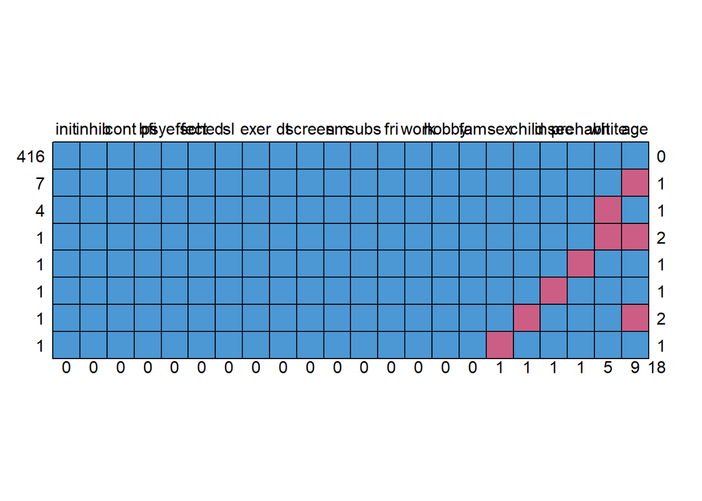

```
##     init inhib cont bfi psyeffect sched sl exer dt screen sm subs fri work
## 416    1     1    1   1         1     1  1    1  1      1  1    1   1    1
## 7      1     1    1   1         1     1  1    1  1      1  1    1   1    1
## 4      1     1    1   1         1     1  1    1  1      1  1    1   1    1
## 1      1     1    1   1         1     1  1    1  1      1  1    1   1    1
## 1      1     1    1   1         1     1  1    1  1      1  1    1   1    1
## 1      1     1    1   1         1     1  1    1  1      1  1    1   1    1
## 1      1     1    1   1         1     1  1    1  1      1  1    1   1    1
## 1      1     1    1   1         1     1  1    1  1      1  1    1   1    1
##        0     0    0   0         0     0  0    0  0      0  0    0   0    0
##     hobby fam sex child insec prehabit white age
## 416     1   1   1     1     1        1     1   1  0
## 7       1   1   1     1     1        1     1   0  1
## 4       1   1   1     1     1        1     0   1  1
## 1       1   1   1     1     1        1     0   0  2
## 1       1   1   1     1     1        0     1   1  1
## 1       1   1   1     1     0        1     1   1  1
## 1       1   1   1     0     1        1     1   0  2
## 1       1   1   0     1     1        1     1   1  1
##         0   0   1     1     1        1     5   9 18
```

```r
md.pattern(habit)
```

This is a really cool output. Both windows show you the same information. On top, on the horizontal axis are the variables. On the left vertical axis are the sums of participants within a given missing data pattern across all variables. On the bottom horizontal axis are the sums of participants with missing data on each variable/column. A missing data pattern is basically each combination of missing data that we can find. That’s represented on the right vertical axis. For example, you can see that there are 8 missing data patterns. The first is no missing data for 416 participants. The second is missing data on one 1 (right vertical axis) variable (age) for 7 participants (left vertical axis). The fourth missing data pattern is for 2 (right vertical axis) variables (age and race) for 1 participant (left vertical axis). And so on.

```r
habit.sem <- "disrupt =~ psyeffect + sched + insec # Our latent variable 1 with 3 indicators
          sreg =~ init + inhib + cont + bfi # Our latent variable 2 with 4 indicators

          sl + exer + dt + subs ~ disrupt + sreg + prehabit + age + sex + white + child

          # Our regression with sl, exer, dt, and subs as endogenous variables and all else as exogenous
          # Note that we have a combination of latent and observed variables for exogenous variables
          # All endogeous are observed

          sreg ~~ disrupt + prehabit + age + sex + white + child # Covariances between exogenous variables
          disrupt ~~ prehabit + age + sex + white + child
          prehabit ~~ age + sex + white + child
          age ~~ sex + white + child
          sex ~~ white + child
          white ~~ child
          "
```

Then we estimate the model as we did before

```r
cont.fit <- sem(
  model = habit.sem, # tell R the model you're using (we specified it above and gave it a name)
  data = habit, # Tell R the dataset you're using (we gave it a name above)
  missing = "fiml", # Listiwse is the default, and we know there's a lot of missing data
  estimator = "mlr" # Tell R the estimator we're using
)

summary(cont.fit, # Tell R which model to output
        fit.measures = TRUE,# Tell R you want the fit measures (CFI, TLI etc.)
        standardized = TRUE) # Tell R you want the standardized solution
```

```
## lavaan 0.6-9 ended normally after 141 iterations
##
##   Estimator                                         ML
##   Optimization method                           NLMINB
##   Number of model parameters                        94
##
##   Number of observations                           432
##   Number of missing patterns                         8
##
## Model Test User Model:
##                                                Standard      Robust
##   Test Statistic                                164.661     166.366
##   Degrees of freedom                                 58          58
##   P-value (Chi-square)                            0.000       0.000
##   Scaling correction factor                                   0.990
##        Yuan-Bentler correction (Mplus variant)
##
## Model Test Baseline Model:
##
##   Test statistic                              1223.810    1182.152
##   Degrees of freedom                               120         120
##   P-value                                        0.000       0.000
##   Scaling correction factor                                  1.035
##
## User Model versus Baseline Model:
##
##   Comparative Fit Index (CFI)                    0.903       0.898
##   Tucker-Lewis Index (TLI)                       0.800       0.789
##
##   Robust Comparative Fit Index (CFI)                         0.902
##   Robust Tucker-Lewis Index (TLI)                            0.798
##
## Loglikelihood and Information Criteria:
##
##   Loglikelihood user model (H0)              -8314.432   -8314.432
##   Scaling correction factor                                  0.984
##       for the MLR correction
##   Loglikelihood unrestricted model (H1)      -8232.102   -8232.102
##   Scaling correction factor                                  0.986
##       for the MLR correction
```

[output cut: 139 more lines]

```
##    .init              0.311    0.034    9.053    0.000    0.311    0.331
##    .inhib             0.371    0.025   14.936    0.000    0.371    0.766
##    .cont              0.318    0.029   11.123    0.000    0.318    0.572
##    .bfi               0.113    0.020    5.710    0.000    0.113    0.227
##    .sl                0.599    0.027   21.976    0.000    0.599    0.929
##    .exer              0.683    0.030   22.816    0.000    0.683    0.934
##    .dt                0.370    0.023   16.029    0.000    0.370    0.981
##    .subs              0.545    0.029   18.762    0.000    0.545    0.923
##     prehabit          0.452    0.032   13.991    0.000    0.452    1.000
##     age             131.838   10.579   12.462    0.000  131.838    1.000
##     sex               0.241    0.004   54.251    0.000    0.241    1.000
##     white             0.221    0.008   28.625    0.000    0.221    1.000
##     child             0.241    0.004   54.240    0.000    0.241    1.000
##     disrupt           0.463    0.091    5.095    0.000    1.000    1.000
##     sreg              0.628    0.058   10.808    0.000    1.000    1.000
```

We’ll show you two options for MI in R. On the first, you’ll create the imputed dataset using a flexible MI package called mice, then you’ll fit your lavaan model to your datasets using semTools package.

In the second method, we’ll just use the semTools package to do MI and fit the models. In both cases you’ll need to download semTools (if your first time using it) and then load the library (every time you use it within an R session).

We’ll first do the two-part method in which we mice to do multiple imputation with Bayesian regression, as in Mplus. This is the Rubin (1987) and Schafer (1997) method. The function for this algorithm is called “norm”.

```r
# install.packages('semTools')
library(semTools)
habit.imp <- mice(habit, # the dataframe name
                 maxit = 0, # A scalar giving the number of iterations, default is 5
                 m = 10, # Number of imputed datasets, default is 5
                 defaultMethod = "norm") # The method we're choosing, which is norm
```

```r
mice.imp <- NULL
for (i in 1:10) mice.imp[[i]] <- complete(habit.imp, action = i,
    inc = FALSE)  # On this line, you'll need to change the 1:5 (one through 5) if you have more than 5 datasets. E.g., if you have 10, you'll need to change this into 1:10.
```

We then fit the model.

```r
impsem <- runMI(habit.sem, # Tell R the model we specified earlier
              data = mice.imp, # Tell R the imputed datasets that we created with mice
              fun = "sem" # tell MI the
              )
```

And we get our output

```r
summary(impsem, # Tell R which model to output
        fit.measures = TRUE,# Tell R you want the fit measures (CFI, TLI etc.)
        standardized = TRUE) # Tell R you want the standardized solution
```

```
## lavaan.mi object based on 10 imputed data sets.
## See class?lavaan.mi help page for available methods.
##
## Convergence information:
## The model converged on 10 imputed data sets
##
## Rubin's (1987) rules were used to pool point and SE estimates across 10 imputed data sets, and to calculate degrees of freedom for each parameter's t test and CI.
##
## Model Test User Model:
##
##   Test statistic                               160.779
##   Degrees of freedom                                58
##   P-value                                        0.000
##
## Model Test Baseline Model:
##
##   Test statistic                              1210.829
##   Degrees of freedom                               120
##   P-value                                        0.000
##
## User Model versus Baseline Model:
##
##   Comparative Fit Index (CFI)                    0.906
##   Tucker-Lewis Index (TLI)                       0.805
##
## Root Mean Square Error of Approximation:
##
##   RMSEA                                          0.064
##   90 Percent confidence interval - lower         0.052
##   90 Percent confidence interval - upper         0.076
##   P-value RMSEA <= 0.05                          0.025
##
## Standardized Root Mean Square Residual:
##
##   SRMR                                           0.038
```

```
##
## Parameter Estimates:
##
##   Standard errors                             Standard
##   Information                                 Expected
##   Information saturated (h1) model          Structured
##
## Latent Variables:
##                    Estimate  Std.Err  t-value       df  P(>|t|)   Std.lv
##   disrupt =~
##     psyeffect         1.000                                        0.681
##     sched             1.067    0.103   10.346      Inf    0.000    0.727
##     insec             1.014    0.114    8.917      Inf    0.000    0.691
##   sreg =~
##     init              1.000                                        0.792
##     inhib             0.425    0.044    9.749      Inf    0.000    0.336
##     cont              0.616    0.045   13.708      Inf    0.000    0.488
##     bfi               0.782    0.045   17.270      Inf    0.000    0.619
##   Std.all
##
##     0.725
##     0.748
##     0.535
##
##     0.818
##     0.483
##     0.654
##     0.879
##
## Regressions:
##                    Estimate  Std.Err  t-value       df  P(>|t|)   Std.lv
##   sl ~
##     disrupt          -0.316    0.073   -4.347      Inf    0.000   -0.215
##     sreg             -0.027    0.056   -0.476      Inf    0.634   -0.021
##     prehabit         -0.029    0.060   -0.488      Inf    0.626   -0.029
##     age              -0.001    0.003   -0.262      Inf    0.794   -0.001
##     sex              -0.016    0.079   -0.202      Inf    0.840   -0.016
##     white            -0.066    0.082   -0.798      Inf    0.425   -0.066
##     child             0.134    0.082    1.632      Inf    0.103    0.134
##   exer ~
```

[output cut: 159 more lines]

```
##     0.331
##     0.767
##     0.572
##     0.227
##     0.929
##     0.933
##     0.981
##     0.923
##     1.000
##     1.000
##     1.000
##     1.000
##     1.000
##     1.000
##     1.000
```

Now let’s do the second method, in which we use semTools to do MI and fit the model in one go.

```r
impsem2 <- runMI(habit.sem, # tell which model to estimate
              data = habit, # tell which data to use
              m = 5, # how many datasets we're creating
              miPackage = "mice", # which package we're using to do MI
              fun = "sem", # the sem function we're using to estimate the model
              meanstructure = TRUE) # whether we also want the mean structure to be estimated

summary(impsem2, # Tell R which model to output
        fit.measures = TRUE,# Tell R you want the fit measures (CFI, TLI etc.)
        standardized = TRUE) # Tell R you want the standardized solution
```

```
## lavaan.mi object based on 5 imputed data sets.
## See class?lavaan.mi help page for available methods.
##
## Convergence information:
## The model converged on 5 imputed data sets
##
## Rubin's (1987) rules were used to pool point and SE estimates across 5 imputed data sets, and to calculate degrees of freedom for each parameter's t test and CI.
##
## Model Test User Model:
##
##   Test statistic                               165.643
##   Degrees of freedom                                58
##   P-value                                        0.000
##
## Model Test Baseline Model:
##
##   Test statistic                              1222.707
##   Degrees of freedom                               120
##   P-value                                        0.000
##
## User Model versus Baseline Model:
##
##   Comparative Fit Index (CFI)                    0.902
##   Tucker-Lewis Index (TLI)                       0.798
##
## Root Mean Square Error of Approximation:
##
##   RMSEA                                          0.066
##   90 Percent confidence interval - lower         0.054
##   90 Percent confidence interval - upper         0.077
##   P-value RMSEA <= 0.05                          0.015
##
## Standardized Root Mean Square Residual:
##
##   SRMR                                           0.036
```

```
##
## Parameter Estimates:
##
##   Standard errors                             Standard
##   Information                                 Expected
##   Information saturated (h1) model          Structured
##
## Latent Variables:
##                    Estimate  Std.Err  t-value       df  P(>|t|)   Std.lv
##   disrupt =~
##     psyeffect         1.000                                        0.680
##     sched             1.071    0.103   10.414      Inf    0.000    0.728
##     insec             1.027    0.114    9.016      Inf    0.000    0.698
##   sreg =~
##     init              1.000                                        0.792
##     inhib             0.424    0.043    9.757      Inf    0.000    0.336
##     cont              0.616    0.045   13.719      Inf    0.000    0.488
##     bfi               0.781    0.045   17.287      Inf    0.000    0.619
##   Std.all
##
##     0.724
##     0.749
##     0.540
##
##     0.818
##     0.483
##     0.654
##     0.879
##
## Regressions:
##                    Estimate  Std.Err  t-value       df  P(>|t|)   Std.lv
##   sl ~
##     disrupt          -0.318    0.073   -4.376      Inf    0.000   -0.216
##     sreg             -0.027    0.056   -0.475      Inf    0.635   -0.021
##     prehabit         -0.027    0.060   -0.449      Inf    0.654   -0.027
##     age              -0.001    0.003   -0.322 4596.669    0.747   -0.001
##     sex              -0.016    0.078   -0.209      Inf    0.834   -0.016
##     white            -0.062    0.082   -0.755 6207.121    0.450   -0.062
##     child             0.137    0.082    1.671      Inf    0.095    0.137
##   exer ~
```

[output cut: 199 more lines]

```
##     0.331
##     0.767
##     0.572
##     0.227
##     0.929
##     0.934
##     0.981
##     0.922
##     1.000
##     1.000
##     1.000
##     1.000
##     1.000
##     1.000
##     1.000
```